# Risk Factor Analysis

## Outcome Variable

**Outcome Variable:** whz

## Predictor Variables

**Intervention Variable:** single

**Adjustment Set:**

- arm
- W_mage
- meducyrs
- feducyrs
- W_mhtcm
- W_mwtkg
- W_mbmi
- delta_W_mage
- delta_meducyrs
- delta_feducyrs
- delta_W_mhtcm
- delta_W_mwtkg
- delta_W_mbmi

## Stratifying Variables

The analysis was stratified on these variable(s):

- agecat
- studyid
- country

## Data Summary

| agecat | studyid | country | single | n_cell | n | outcome_variable |
| --- | --- | --- | --- | --- | --- | --- |
| Birth | ki0047075b-MAL-ED | BANGLADESH | 0 | 215 | 215 | whz |
| Birth | ki0047075b-MAL-ED | BANGLADESH | 1 | 0 | 215 | whz |
| Birth | ki0047075b-MAL-ED | BRAZIL | 0 | 54 | 62 | whz |
| Birth | ki0047075b-MAL-ED | BRAZIL | 1 | 8 | 62 | whz |
| Birth | ki0047075b-MAL-ED | INDIA | 0 | 45 | 45 | whz |
| Birth | ki0047075b-MAL-ED | INDIA | 1 | 0 | 45 | whz |
| Birth | ki0047075b-MAL-ED | NEPAL | 0 | 26 | 26 | whz |
| Birth | ki0047075b-MAL-ED | NEPAL | 1 | 0 | 26 | whz |
| Birth | ki0047075b-MAL-ED | PERU | 0 | 205 | 228 | whz |
| Birth | ki0047075b-MAL-ED | PERU | 1 | 23 | 228 | whz |
| Birth | ki0047075b-MAL-ED | SOUTH AFRICA | 0 | 63 | 120 | whz |
| Birth | ki0047075b-MAL-ED | SOUTH AFRICA | 1 | 57 | 120 | whz |
| Birth | ki0047075b-MAL-ED | TANZANIA, UNITED REPUBLIC OF | 0 | 112 | 115 | whz |
| Birth | ki0047075b-MAL-ED | TANZANIA, UNITED REPUBLIC OF | 1 | 3 | 115 | whz |
| Birth | ki1119695-PROBIT | BELARUS | 0 | 13291 | 13830 | whz |
| Birth | ki1119695-PROBIT | BELARUS | 1 | 539 | 13830 | whz |
| Birth | ki1126311-ZVITAMBO | ZIMBABWE | 0 | 12065 | 12864 | whz |
| Birth | ki1126311-ZVITAMBO | ZIMBABWE | 1 | 799 | 12864 | whz |
| Birth | ki1135781-COHORTS | GUATEMALA | 0 | 654 | 691 | whz |
| Birth | ki1135781-COHORTS | GUATEMALA | 1 | 37 | 691 | whz |
| Birth | ki1135781-COHORTS | INDIA | 0 | 4456 | 4463 | whz |
| Birth | ki1135781-COHORTS | INDIA | 1 | 7 | 4463 | whz |
| Birth | ki1135781-COHORTS | PHILIPPINES | 0 | 2789 | 2860 | whz |
| Birth | ki1135781-COHORTS | PHILIPPINES | 1 | 71 | 2860 | whz |
| Birth | kiGH5241-JiVitA-4 | BANGLADESH | 0 | 2388 | 2393 | whz |
| Birth | kiGH5241-JiVitA-4 | BANGLADESH | 1 | 5 | 2393 | whz |
| 6 months | ki0047075b-MAL-ED | BANGLADESH | 0 | 241 | 241 | whz |
| 6 months | ki0047075b-MAL-ED | BANGLADESH | 1 | 0 | 241 | whz |
| 6 months | ki0047075b-MAL-ED | BRAZIL | 0 | 179 | 209 | whz |
| 6 months | ki0047075b-MAL-ED | BRAZIL | 1 | 30 | 209 | whz |

[output cut: 54 more lines]

The following strata were considered:

- agecat: 24 months, studyid: ki0047075b-MAL-ED, country: BANGLADESH
- agecat: 24 months, studyid: ki0047075b-MAL-ED, country: BRAZIL
- agecat: 24 months, studyid: ki0047075b-MAL-ED, country: INDIA
- agecat: 24 months, studyid: ki0047075b-MAL-ED, country: NEPAL
- agecat: 24 months, studyid: ki0047075b-MAL-ED, country: PERU
- agecat: 24 months, studyid: ki0047075b-MAL-ED, country: SOUTH AFRICA
- agecat: 24 months, studyid: ki0047075b-MAL-ED, country: TANZANIA, UNITED REPUBLIC OF
- agecat: 24 months, studyid: ki1066203-TanzaniaChild2, country: TANZANIA, UNITED REPUBLIC OF
- agecat: 24 months, studyid: ki1119695-PROBIT, country: BELARUS
- agecat: 24 months, studyid: ki1126311-ZVITAMBO, country: ZIMBABWE
- agecat: 24 months, studyid: ki1135781-COHORTS, country: GUATEMALA
- agecat: 24 months, studyid: ki1135781-COHORTS, country: INDIA
- agecat: 24 months, studyid: ki1135781-COHORTS, country: PHILIPPINES
- agecat: 24 months, studyid: kiGH5241-JiVitA-4, country: BANGLADESH
- agecat: 6 months, studyid: ki0047075b-MAL-ED, country: BANGLADESH
- agecat: 6 months, studyid: ki0047075b-MAL-ED, country: BRAZIL
- agecat: 6 months, studyid: ki0047075b-MAL-ED, country: INDIA
- agecat: 6 months, studyid: ki0047075b-MAL-ED, country: NEPAL
- agecat: 6 months, studyid: ki0047075b-MAL-ED, country: PERU
- agecat: 6 months, studyid: ki0047075b-MAL-ED, country: SOUTH AFRICA
- agecat: 6 months, studyid: ki0047075b-MAL-ED, country: TANZANIA, UNITED REPUBLIC OF
- agecat: 6 months, studyid: ki1066203-TanzaniaChild2, country: TANZANIA, UNITED REPUBLIC OF
- agecat: 6 months, studyid: ki1112895-Guatemala BSC, country: GUATEMALA
- agecat: 6 months, studyid: ki1119695-PROBIT, country: BELARUS
- agecat: 6 months, studyid: ki1126311-ZVITAMBO, country: ZIMBABWE
- agecat: 6 months, studyid: ki1135781-COHORTS, country: GUATEMALA
- agecat: 6 months, studyid: ki1135781-COHORTS, country: INDIA
- agecat: 6 months, studyid: ki1135781-COHORTS, country: PHILIPPINES
- agecat: 6 months, studyid: kiGH5241-JiVitA-4, country: BANGLADESH
- agecat: Birth, studyid: ki0047075b-MAL-ED, country: BANGLADESH
- agecat: Birth, studyid: ki0047075b-MAL-ED, country: BRAZIL
- agecat: Birth, studyid: ki0047075b-MAL-ED, country: INDIA
- agecat: Birth, studyid: ki0047075b-MAL-ED, country: NEPAL
- agecat: Birth, studyid: ki0047075b-MAL-ED, country: PERU
- agecat: Birth, studyid: ki0047075b-MAL-ED, country: SOUTH AFRICA
- agecat: Birth, studyid: ki0047075b-MAL-ED, country: TANZANIA, UNITED REPUBLIC OF
- agecat: Birth, studyid: ki1119695-PROBIT, country: BELARUS
- agecat: Birth, studyid: ki1126311-ZVITAMBO, country: ZIMBABWE
- agecat: Birth, studyid: ki1135781-COHORTS, country: GUATEMALA
- agecat: Birth, studyid: ki1135781-COHORTS, country: INDIA
- agecat: Birth, studyid: ki1135781-COHORTS, country: PHILIPPINES
- agecat: Birth, studyid: kiGH5241-JiVitA-4, country: BANGLADESH

### Dropped Strata

- agecat: Birth, studyid: ki0047075b-MAL-ED, country: BANGLADESH
- agecat: Birth, studyid: ki0047075b-MAL-ED, country: INDIA
- agecat: Birth, studyid: ki0047075b-MAL-ED, country: NEPAL
- agecat: Birth, studyid: ki0047075b-MAL-ED, country: TANZANIA, UNITED REPUBLIC OF
- agecat: 6 months, studyid: ki0047075b-MAL-ED, country: BANGLADESH
- agecat: 6 months, studyid: ki0047075b-MAL-ED, country: INDIA
- agecat: 6 months, studyid: ki0047075b-MAL-ED, country: NEPAL
- agecat: 24 months, studyid: ki0047075b-MAL-ED, country: BANGLADESH
- agecat: 24 months, studyid: ki0047075b-MAL-ED, country: INDIA
- agecat: 24 months, studyid: ki0047075b-MAL-ED, country: NEPAL
- agecat: 24 months, studyid: ki1066203-TanzaniaChild2, country: TANZANIA, UNITED REPUBLIC OF

## Methods Detail

We’re interested in the causal parameters $E[Y_a]$ for all values of $a \in \mathcal{A}$. These parameters represent the mean outcome if, possibly contrary to fact, we intervened to set all units to have $A=a$. Under the randomization and positivity assumptions, these are identified by the statistical parameters $\psi_a=E_W[E_{Y|A,W}(Y|A=a,W)]$. In addition, we’re interested in the mean of $Y$, $E[Y]$ under no intervention (the observed mean). We will estimate these parameters by using SuperLearner to fit the relevant likelihood factors – $E_{Y|A,W}(Y|A=a,W)$ and $p(A=a|W)$, and then updating our likelihood fit using a joint TMLE.

For unadjusted analyses ($W=\{\}$), initial likelihoods were estimated using Lrnr_glm to estimate the simple $E(Y|A)$ and Lrnr_mean to estimate $p(A)$. For adjusted analyses, a small library containing Lrnr_glmnet, Lrnr_xgboost, and Lrnr_mean was used.

# Results Detail

## Results Plots

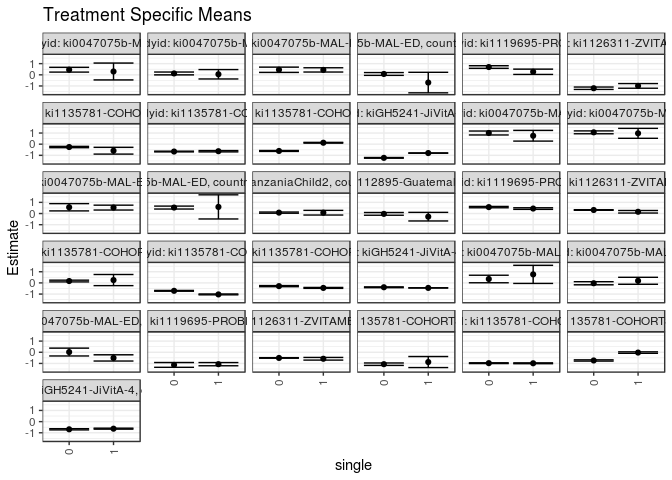

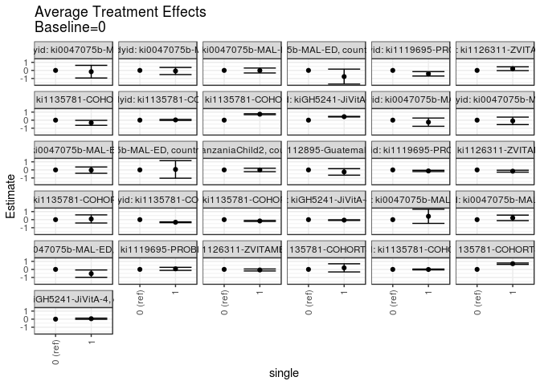

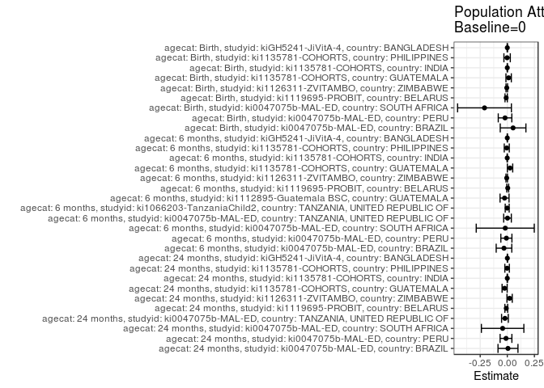

## Results Table

### Parameter: TSM

| agecat | studyid | country | intervention_level | baseline_level | estimate | ci_lower | ci_upper |
| --- | --- | --- | --- | --- | --- | --- | --- |
| Birth | ki0047075b-MAL-ED | BRAZIL | 0 | NA | 0.3496296 | 0.0129664 | 0.6862928 |
| Birth | ki0047075b-MAL-ED | BRAZIL | 1 | NA | 0.7625000 | -0.0474852 | 1.5724852 |
| Birth | ki0047075b-MAL-ED | PERU | 0 | NA | -0.0311019 | -0.1711779 | 0.1089742 |
| Birth | ki0047075b-MAL-ED | PERU | 1 | NA | 0.1892413 | -0.1230526 | 0.5015351 |
| Birth | ki0047075b-MAL-ED | SOUTH AFRICA | 0 | NA | 0.0177169 | -0.3334151 | 0.3688489 |
| Birth | ki0047075b-MAL-ED | SOUTH AFRICA | 1 | NA | -0.5082627 | -0.7879547 | -0.2285707 |
| Birth | ki1119695-PROBIT | BELARUS | 0 | NA | -1.1344163 | -1.3475913 | -0.9212413 |
| Birth | ki1119695-PROBIT | BELARUS | 1 | NA | -1.0668044 | -1.2092499 | -0.9243589 |
| Birth | ki1126311-ZVITAMBO | ZIMBABWE | 0 | NA | -0.5100469 | -0.5368935 | -0.4832003 |
| Birth | ki1126311-ZVITAMBO | ZIMBABWE | 1 | NA | -0.5832748 | -0.7025334 | -0.4640163 |
| Birth | ki1135781-COHORTS | GUATEMALA | 0 | NA | -1.0674725 | -1.1770721 | -0.9578729 |
| Birth | ki1135781-COHORTS | GUATEMALA | 1 | NA | -0.8757348 | -1.3695016 | -0.3819680 |
| Birth | ki1135781-COHORTS | INDIA | 0 | NA | -0.9764901 | -1.0121932 | -0.9407871 |
| Birth | ki1135781-COHORTS | INDIA | 1 | NA | -0.9871429 | -1.0249916 | -0.9492941 |
| Birth | ki1135781-COHORTS | PHILIPPINES | 0 | NA | -0.7359624 | -0.7927564 | -0.6791684 |
| Birth | ki1135781-COHORTS | PHILIPPINES | 1 | NA | -0.0287331 | -0.0953268 | 0.0378605 |
| Birth | kiGH5241-JiVitA-4 | BANGLADESH | 0 | NA | -0.6889322 | -0.7427226 | -0.6351417 |
| Birth | kiGH5241-JiVitA-4 | BANGLADESH | 1 | NA | -0.6340000 | -0.6780019 | -0.5899981 |
| 6 months | ki0047075b-MAL-ED | BRAZIL | 0 | NA | 1.0026331 | 0.8266654 | 1.1786008 |
| 6 months | ki0047075b-MAL-ED | BRAZIL | 1 | NA | 0.7538643 | 0.2744557 | 1.2332729 |
| 6 months | ki0047075b-MAL-ED | PERU | 0 | NA | 1.0613881 | 0.9343100 | 1.1884663 |
| 6 months | ki0047075b-MAL-ED | PERU | 1 | NA | 0.9719301 | 0.5277209 | 1.4161394 |
| 6 months | ki0047075b-MAL-ED | SOUTH AFRICA | 0 | NA | 0.5612278 | 0.2343072 | 0.8881484 |
| 6 months | ki0047075b-MAL-ED | SOUTH AFRICA | 1 | NA | 0.5331912 | 0.3151019 | 0.7512805 |
| 6 months | ki0047075b-MAL-ED | TANZANIA, UNITED REPUBLIC OF | 0 | NA | 0.5343375 | 0.4035792 | 0.6650959 |
| 6 months | ki0047075b-MAL-ED | TANZANIA, UNITED REPUBLIC OF | 1 | NA | 0.5925000 | -0.4882365 | 1.6732365 |
| 6 months | ki1066203-TanzaniaChild2 | TANZANIA, UNITED REPUBLIC OF | 0 | NA | 0.0807672 | 0.0260047 | 0.1355298 |
| 6 months | ki1066203-TanzaniaChild2 | TANZANIA, UNITED REPUBLIC OF | 1 | NA | 0.0762918 | -0.1322452 | 0.2848288 |
| 6 months | ki1112895-Guatemala BSC | GUATEMALA | 0 | NA | -0.0315206 | -0.1527440 | 0.0897027 |
| 6 months | ki1112895-Guatemala BSC | GUATEMALA | 1 | NA | -0.2807385 | -0.6670200 | 0.1055430 |
| 6 months | ki1119695-PROBIT | BELARUS | 0 | NA | 0.5752877 | 0.5155020 | 0.6350735 |
| 6 months | ki1119695-PROBIT | BELARUS | 1 | NA | 0.4472408 | 0.3770023 | 0.5174793 |
| 6 months | ki1126311-ZVITAMBO | ZIMBABWE | 0 | NA | 0.3163237 | 0.2897004 | 0.3429470 |
| 6 months | ki1126311-ZVITAMBO | ZIMBABWE | 1 | NA | 0.1575850 | 0.0436816 | 0.2714884 |
| 6 months | ki1135781-COHORTS | GUATEMALA | 0 | NA | 0.1668695 | 0.0904959 | 0.2432432 |
| 6 months | ki1135781-COHORTS | GUATEMALA | 1 | NA | 0.2526469 | -0.2450522 | 0.7503460 |
| 6 months | ki1135781-COHORTS | INDIA | 0 | NA | -0.7098951 | -0.7430287 | -0.6767615 |
| 6 months | ki1135781-COHORTS | INDIA | 1 | NA | -1.0322222 | -1.0700926 | -0.9943519 |
| 6 months | ki1135781-COHORTS | PHILIPPINES | 0 | NA | -0.2887429 | -0.3373849 | -0.2401010 |
| 6 months | ki1135781-COHORTS | PHILIPPINES | 1 | NA | -0.4496963 | -0.4894747 | -0.4099179 |
| 6 months | kiGH5241-JiVitA-4 | BANGLADESH | 0 | NA | -0.3903686 | -0.4286532 | -0.3520840 |
| 6 months | kiGH5241-JiVitA-4 | BANGLADESH | 1 | NA | -0.4493750 | -0.4619543 | -0.4367957 |
| 24 months | ki0047075b-MAL-ED | BRAZIL | 0 | NA | 0.4563231 | 0.2431715 | 0.6694748 |
| 24 months | ki0047075b-MAL-ED | BRAZIL | 1 | NA | 0.2975976 | -0.4580265 | 1.0532217 |
| 24 months | ki0047075b-MAL-ED | PERU | 0 | NA | 0.1232085 | -0.0044065 | 0.2508236 |
| 24 months | ki0047075b-MAL-ED | PERU | 1 | NA | 0.0496243 | -0.3726017 | 0.4718503 |
| 24 months | ki0047075b-MAL-ED | SOUTH AFRICA | 0 | NA | 0.4521386 | 0.2155351 | 0.6887421 |
| 24 months | ki0047075b-MAL-ED | SOUTH AFRICA | 1 | NA | 0.4387371 | 0.2475518 | 0.6299224 |
| 24 months | ki0047075b-MAL-ED | TANZANIA, UNITED REPUBLIC OF | 0 | NA | 0.0763782 | -0.0483716 | 0.2011280 |
| 24 months | ki0047075b-MAL-ED | TANZANIA, UNITED REPUBLIC OF | 1 | NA | -0.6933333 | -1.6135001 | 0.2268334 |
| 24 months | ki1119695-PROBIT | BELARUS | 0 | NA | 0.6967001 | 0.5800528 | 0.8133473 |
| 24 months | ki1119695-PROBIT | BELARUS | 1 | NA | 0.2716000 | 0.0345280 | 0.5086720 |
| 24 months | ki1126311-ZVITAMBO | ZIMBABWE | 0 | NA | -1.2008806 | -1.3082426 | -1.0935187 |
| 24 months | ki1126311-ZVITAMBO | ZIMBABWE | 1 | NA | -0.9922788 | -1.2024586 | -0.7820989 |
| 24 months | ki1135781-COHORTS | GUATEMALA | 0 | NA | -0.2549680 | -0.3131834 | -0.1967526 |
| 24 months | ki1135781-COHORTS | GUATEMALA | 1 | NA | -0.5862149 | -0.8894958 | -0.2829340 |
| 24 months | ki1135781-COHORTS | INDIA | 0 | NA | -0.6594835 | -0.6934635 | -0.6255034 |
| 24 months | ki1135781-COHORTS | INDIA | 1 | NA | -0.6300000 | -0.6887577 | -0.5712423 |
| 24 months | ki1135781-COHORTS | PHILIPPINES | 0 | NA | -0.6081826 | -0.6513421 | -0.5650232 |
| 24 months | ki1135781-COHORTS | PHILIPPINES | 1 | NA | 0.1287629 | 0.0943983 | 0.1631274 |
| 24 months | kiGH5241-JiVitA-4 | BANGLADESH | 0 | NA | -1.2245351 | -1.2573027 | -1.1917674 |
| 24 months | kiGH5241-JiVitA-4 | BANGLADESH | 1 | NA | -0.7950000 | -0.8090439 | -0.7809561 |

### Parameter: E(Y)

| agecat | studyid | country | intervention_level | baseline_level | estimate | ci_lower | ci_upper |
| --- | --- | --- | --- | --- | --- | --- | --- |
| Birth | ki0047075b-MAL-ED | BRAZIL | NA | NA | 0.4029032 | 0.0896793 | 0.7161272 |
| Birth | ki0047075b-MAL-ED | PERU | NA | NA | -0.0520175 | -0.1725298 | 0.0684947 |
| Birth | ki0047075b-MAL-ED | SOUTH AFRICA | NA | NA | -0.1925833 | -0.4053570 | 0.0201904 |
| Birth | ki1119695-PROBIT | BELARUS | NA | NA | -1.1448633 | -1.3544229 | -0.9353037 |
| Birth | ki1126311-ZVITAMBO | ZIMBABWE | NA | NA | -0.5148609 | -0.5407634 | -0.4889583 |
| Birth | ki1135781-COHORTS | GUATEMALA | NA | NA | -1.0552243 | -1.1617873 | -0.9486614 |
| Birth | ki1135781-COHORTS | INDIA | NA | NA | -0.9765068 | -1.0113301 | -0.9416835 |
| Birth | ki1135781-COHORTS | PHILIPPINES | NA | NA | -0.7377902 | -0.7844819 | -0.6910986 |
| Birth | kiGH5241-JiVitA-4 | BANGLADESH | NA | NA | -0.6888174 | -0.7412201 | -0.6364147 |
| 6 months | ki0047075b-MAL-ED | BRAZIL | NA | NA | 0.9720774 | 0.8078144 | 1.1363403 |
| 6 months | ki0047075b-MAL-ED | PERU | NA | NA | 1.0528816 | 0.9313005 | 1.1744626 |
| 6 months | ki0047075b-MAL-ED | SOUTH AFRICA | NA | NA | 0.5421785 | 0.3900443 | 0.6943126 |
| 6 months | ki0047075b-MAL-ED | TANZANIA, UNITED REPUBLIC OF | NA | NA | 0.5362213 | 0.4049390 | 0.6675036 |
| 6 months | ki1066203-TanzaniaChild2 | TANZANIA, UNITED REPUBLIC OF | NA | NA | 0.0797577 | 0.0268998 | 0.1326156 |
| 6 months | ki1112895-Guatemala BSC | GUATEMALA | NA | NA | -0.0568833 | -0.1722874 | 0.0585208 |
| 6 months | ki1119695-PROBIT | BELARUS | NA | NA | 0.5792439 | 0.5193388 | 0.6391490 |
| 6 months | ki1126311-ZVITAMBO | ZIMBABWE | NA | NA | 0.3108992 | 0.2851818 | 0.3366167 |
| 6 months | ki1135781-COHORTS | GUATEMALA | NA | NA | 0.1920134 | 0.1173734 | 0.2666534 |
| 6 months | ki1135781-COHORTS | INDIA | NA | NA | -0.7104795 | -0.7428008 | -0.6781581 |
| 6 months | ki1135781-COHORTS | PHILIPPINES | NA | NA | -0.2936948 | -0.3352840 | -0.2521057 |
| 6 months | kiGH5241-JiVitA-4 | BANGLADESH | NA | NA | -0.3904664 | -0.4277855 | -0.3531473 |
| 24 months | ki0047075b-MAL-ED | BRAZIL | NA | NA | 0.4626233 | 0.2567495 | 0.6684971 |
| 24 months | ki0047075b-MAL-ED | PERU | NA | NA | 0.1111982 | -0.0118399 | 0.2342362 |
| 24 months | ki0047075b-MAL-ED | SOUTH AFRICA | NA | NA | 0.4090301 | 0.2879441 | 0.5301161 |
| 24 months | ki0047075b-MAL-ED | TANZANIA, UNITED REPUBLIC OF | NA | NA | 0.0547975 | -0.0703378 | 0.1799328 |
| 24 months | ki1119695-PROBIT | BELARUS | NA | NA | 0.6874295 | 0.5756922 | 0.7991668 |
| 24 months | ki1126311-ZVITAMBO | ZIMBABWE | NA | NA | -1.1797222 | -1.2787189 | -1.0807256 |
| 24 months | ki1135781-COHORTS | GUATEMALA | NA | NA | -0.2796964 | -0.3351582 | -0.2242346 |
| 24 months | ki1135781-COHORTS | INDIA | NA | NA | -0.6594122 | -0.6925753 | -0.6262491 |
| 24 months | ki1135781-COHORTS | PHILIPPINES | NA | NA | -0.6100579 | -0.6471813 | -0.5729344 |
| 24 months | kiGH5241-JiVitA-4 | BANGLADESH | NA | NA | -1.2239898 | -1.2559235 | -1.1920562 |

### Parameter: ATE

| agecat | studyid | country | intervention_level | baseline_level | estimate | ci_lower | ci_upper |
| --- | --- | --- | --- | --- | --- | --- | --- |
| Birth | ki0047075b-MAL-ED | BRAZIL | 0 | 0 | 0.0000000 | 0.0000000 | 0.0000000 |
| Birth | ki0047075b-MAL-ED | BRAZIL | 1 | 0 | 0.4128704 | -0.4642944 | 1.2900352 |
| Birth | ki0047075b-MAL-ED | PERU | 0 | 0 | 0.0000000 | 0.0000000 | 0.0000000 |
| Birth | ki0047075b-MAL-ED | PERU | 1 | 0 | 0.2203431 | -0.1217266 | 0.5624129 |
| Birth | ki0047075b-MAL-ED | SOUTH AFRICA | 0 | 0 | 0.0000000 | 0.0000000 | 0.0000000 |
| Birth | ki0047075b-MAL-ED | SOUTH AFRICA | 1 | 0 | -0.5259797 | -0.9800796 | -0.0718797 |
| Birth | ki1119695-PROBIT | BELARUS | 0 | 0 | 0.0000000 | 0.0000000 | 0.0000000 |
| Birth | ki1119695-PROBIT | BELARUS | 1 | 0 | 0.0676119 | -0.1226710 | 0.2578948 |
| Birth | ki1126311-ZVITAMBO | ZIMBABWE | 0 | 0 | 0.0000000 | 0.0000000 | 0.0000000 |
| Birth | ki1126311-ZVITAMBO | ZIMBABWE | 1 | 0 | -0.0732279 | -0.1954182 | 0.0489624 |
| Birth | ki1135781-COHORTS | GUATEMALA | 0 | 0 | 0.0000000 | 0.0000000 | 0.0000000 |
| Birth | ki1135781-COHORTS | GUATEMALA | 1 | 0 | 0.1917377 | -0.3143191 | 0.6977945 |
| Birth | ki1135781-COHORTS | INDIA | 0 | 0 | 0.0000000 | 0.0000000 | 0.0000000 |
| Birth | ki1135781-COHORTS | INDIA | 1 | 0 | -0.0106527 | -0.0626838 | 0.0413784 |
| Birth | ki1135781-COHORTS | PHILIPPINES | 0 | 0 | 0.0000000 | 0.0000000 | 0.0000000 |
| Birth | ki1135781-COHORTS | PHILIPPINES | 1 | 0 | 0.7072293 | 0.6197592 | 0.7946994 |
| Birth | kiGH5241-JiVitA-4 | BANGLADESH | 0 | 0 | 0.0000000 | 0.0000000 | 0.0000000 |
| Birth | kiGH5241-JiVitA-4 | BANGLADESH | 1 | 0 | 0.0549322 | -0.0162654 | 0.1261297 |
| 6 months | ki0047075b-MAL-ED | BRAZIL | 0 | 0 | 0.0000000 | 0.0000000 | 0.0000000 |
| 6 months | ki0047075b-MAL-ED | BRAZIL | 1 | 0 | -0.2487688 | -0.7604098 | 0.2628722 |
| 6 months | ki0047075b-MAL-ED | PERU | 0 | 0 | 0.0000000 | 0.0000000 | 0.0000000 |
| 6 months | ki0047075b-MAL-ED | PERU | 1 | 0 | -0.0894580 | -0.5519122 | 0.3729962 |
| 6 months | ki0047075b-MAL-ED | SOUTH AFRICA | 0 | 0 | 0.0000000 | 0.0000000 | 0.0000000 |
| 6 months | ki0047075b-MAL-ED | SOUTH AFRICA | 1 | 0 | -0.0280366 | -0.4200629 | 0.3639898 |
| 6 months | ki0047075b-MAL-ED | TANZANIA, UNITED REPUBLIC OF | 0 | 0 | 0.0000000 | 0.0000000 | 0.0000000 |
| 6 months | ki0047075b-MAL-ED | TANZANIA, UNITED REPUBLIC OF | 1 | 0 | 0.0581625 | -1.0304555 | 1.1467805 |
| 6 months | ki1066203-TanzaniaChild2 | TANZANIA, UNITED REPUBLIC OF | 0 | 0 | 0.0000000 | 0.0000000 | 0.0000000 |
| 6 months | ki1066203-TanzaniaChild2 | TANZANIA, UNITED REPUBLIC OF | 1 | 0 | -0.0044754 | -0.2204150 | 0.2114642 |
| 6 months | ki1112895-Guatemala BSC | GUATEMALA | 0 | 0 | 0.0000000 | 0.0000000 | 0.0000000 |
| 6 months | ki1112895-Guatemala BSC | GUATEMALA | 1 | 0 | -0.2492179 | -0.6537322 | 0.1552964 |
| 6 months | ki1119695-PROBIT | BELARUS | 0 | 0 | 0.0000000 | 0.0000000 | 0.0000000 |
| 6 months | ki1119695-PROBIT | BELARUS | 1 | 0 | -0.1280469 | -0.2077955 | -0.0482983 |
| 6 months | ki1126311-ZVITAMBO | ZIMBABWE | 0 | 0 | 0.0000000 | 0.0000000 | 0.0000000 |
| 6 months | ki1126311-ZVITAMBO | ZIMBABWE | 1 | 0 | -0.1587387 | -0.2756015 | -0.0418760 |
| 6 months | ki1135781-COHORTS | GUATEMALA | 0 | 0 | 0.0000000 | 0.0000000 | 0.0000000 |
| 6 months | ki1135781-COHORTS | GUATEMALA | 1 | 0 | 0.0857773 | -0.4181540 | 0.5897087 |
| 6 months | ki1135781-COHORTS | INDIA | 0 | 0 | 0.0000000 | 0.0000000 | 0.0000000 |
| 6 months | ki1135781-COHORTS | INDIA | 1 | 0 | -0.3223272 | -0.3726461 | -0.2720082 |
| 6 months | ki1135781-COHORTS | PHILIPPINES | 0 | 0 | 0.0000000 | 0.0000000 | 0.0000000 |
| 6 months | ki1135781-COHORTS | PHILIPPINES | 1 | 0 | -0.1609534 | -0.2237399 | -0.0981669 |
| 6 months | kiGH5241-JiVitA-4 | BANGLADESH | 0 | 0 | 0.0000000 | 0.0000000 | 0.0000000 |
| 6 months | kiGH5241-JiVitA-4 | BANGLADESH | 1 | 0 | -0.0590064 | -0.0997170 | -0.0182959 |
| 24 months | ki0047075b-MAL-ED | BRAZIL | 0 | 0 | 0.0000000 | 0.0000000 | 0.0000000 |
| 24 months | ki0047075b-MAL-ED | BRAZIL | 1 | 0 | -0.1587255 | -0.9440810 | 0.6266299 |
| 24 months | ki0047075b-MAL-ED | PERU | 0 | 0 | 0.0000000 | 0.0000000 | 0.0000000 |
| 24 months | ki0047075b-MAL-ED | PERU | 1 | 0 | -0.0735842 | -0.5151434 | 0.3679750 |
| 24 months | ki0047075b-MAL-ED | SOUTH AFRICA | 0 | 0 | 0.0000000 | 0.0000000 | 0.0000000 |
| 24 months | ki0047075b-MAL-ED | SOUTH AFRICA | 1 | 0 | -0.0134015 | -0.3180072 | 0.2912042 |
| 24 months | ki0047075b-MAL-ED | TANZANIA, UNITED REPUBLIC OF | 0 | 0 | 0.0000000 | 0.0000000 | 0.0000000 |
| 24 months | ki0047075b-MAL-ED | TANZANIA, UNITED REPUBLIC OF | 1 | 0 | -0.7697115 | -1.6982961 | 0.1588731 |
| 24 months | ki1119695-PROBIT | BELARUS | 0 | 0 | 0.0000000 | 0.0000000 | 0.0000000 |
| 24 months | ki1119695-PROBIT | BELARUS | 1 | 0 | -0.4251001 | -0.6984043 | -0.1517959 |
| 24 months | ki1126311-ZVITAMBO | ZIMBABWE | 0 | 0 | 0.0000000 | 0.0000000 | 0.0000000 |
| 24 months | ki1126311-ZVITAMBO | ZIMBABWE | 1 | 0 | 0.2086019 | -0.0276539 | 0.4448577 |
| 24 months | ki1135781-COHORTS | GUATEMALA | 0 | 0 | 0.0000000 | 0.0000000 | 0.0000000 |
| 24 months | ki1135781-COHORTS | GUATEMALA | 1 | 0 | -0.3312469 | -0.6401723 | -0.0223216 |
| 24 months | ki1135781-COHORTS | INDIA | 0 | 0 | 0.0000000 | 0.0000000 | 0.0000000 |
| 24 months | ki1135781-COHORTS | INDIA | 1 | 0 | 0.0294835 | -0.0383923 | 0.0973592 |
| 24 months | ki1135781-COHORTS | PHILIPPINES | 0 | 0 | 0.0000000 | 0.0000000 | 0.0000000 |
| 24 months | ki1135781-COHORTS | PHILIPPINES | 1 | 0 | 0.7369455 | 0.6821460 | 0.7917450 |
| 24 months | kiGH5241-JiVitA-4 | BANGLADESH | 0 | 0 | 0.0000000 | 0.0000000 | 0.0000000 |
| 24 months | kiGH5241-JiVitA-4 | BANGLADESH | 1 | 0 | 0.4295351 | 0.3935671 | 0.4655030 |

### Parameter: PAR

| agecat | studyid | country | intervention_level | baseline_level | estimate | ci_lower | ci_upper |
| --- | --- | --- | --- | --- | --- | --- | --- |
| Birth | ki0047075b-MAL-ED | BRAZIL | 0 | NA | 0.0532736 | -0.0651185 | 0.1716657 |
| Birth | ki0047075b-MAL-ED | PERU | 0 | NA | -0.0209157 | -0.0834598 | 0.0416284 |
| Birth | ki0047075b-MAL-ED | SOUTH AFRICA | 0 | NA | -0.2103002 | -0.4584520 | 0.0378515 |
| Birth | ki1119695-PROBIT | BELARUS | 0 | NA | -0.0104470 | -0.0210414 | 0.0001474 |
| Birth | ki1126311-ZVITAMBO | ZIMBABWE | 0 | NA | -0.0048139 | -0.0119665 | 0.0023386 |
| Birth | ki1135781-COHORTS | GUATEMALA | 0 | NA | 0.0122482 | -0.0126015 | 0.0370979 |
| Birth | ki1135781-COHORTS | INDIA | 0 | NA | -0.0000167 | -0.0013175 | 0.0012841 |
| Birth | ki1135781-COHORTS | PHILIPPINES | 0 | NA | -0.0018278 | -0.0312229 | 0.0275673 |
| Birth | kiGH5241-JiVitA-4 | BANGLADESH | 0 | NA | 0.0001148 | -0.0016450 | 0.0018746 |
| 6 months | ki0047075b-MAL-ED | BRAZIL | 0 | NA | -0.0305557 | -0.1024797 | 0.0413682 |
| 6 months | ki0047075b-MAL-ED | PERU | 0 | NA | -0.0085066 | -0.0596175 | 0.0426043 |
| 6 months | ki0047075b-MAL-ED | SOUTH AFRICA | 0 | NA | -0.0190493 | -0.2866797 | 0.2485811 |
| 6 months | ki0047075b-MAL-ED | TANZANIA, UNITED REPUBLIC OF | 0 | NA | 0.0018838 | -0.0333985 | 0.0371662 |
| 6 months | ki1066203-TanzaniaChild2 | TANZANIA, UNITED REPUBLIC OF | 0 | NA | -0.0010095 | -0.0192281 | 0.0172091 |
| 6 months | ki1112895-Guatemala BSC | GUATEMALA | 0 | NA | -0.0253627 | -0.0668163 | 0.0160910 |
| 6 months | ki1119695-PROBIT | BELARUS | 0 | NA | 0.0039561 | -0.0047882 | 0.0127005 |
| 6 months | ki1126311-ZVITAMBO | ZIMBABWE | 0 | NA | -0.0054245 | -0.0123830 | 0.0015340 |
| 6 months | ki1135781-COHORTS | GUATEMALA | 0 | NA | 0.0251439 | 0.0003306 | 0.0499572 |
| 6 months | ki1135781-COHORTS | INDIA | 0 | NA | -0.0005844 | -0.0018989 | 0.0007302 |
| 6 months | ki1135781-COHORTS | PHILIPPINES | 0 | NA | -0.0049519 | -0.0281268 | 0.0182230 |
| 6 months | kiGH5241-JiVitA-4 | BANGLADESH | 0 | NA | -0.0000979 | -0.0011182 | 0.0009225 |
| 24 months | ki0047075b-MAL-ED | BRAZIL | 0 | NA | 0.0063001 | -0.0857601 | 0.0983603 |
| 24 months | ki0047075b-MAL-ED | PERU | 0 | NA | -0.0120103 | -0.0663378 | 0.0423171 |
| 24 months | ki0047075b-MAL-ED | SOUTH AFRICA | 0 | NA | -0.0431085 | -0.2390059 | 0.1527889 |
| 24 months | ki0047075b-MAL-ED | TANZANIA, UNITED REPUBLIC OF | 0 | NA | -0.0215807 | -0.0527095 | 0.0095481 |
| 24 months | ki1119695-PROBIT | BELARUS | 0 | NA | -0.0092706 | -0.0222439 | 0.0037027 |
| 24 months | ki1126311-ZVITAMBO | ZIMBABWE | 0 | NA | 0.0211584 | -0.0031511 | 0.0454680 |
| 24 months | ki1135781-COHORTS | GUATEMALA | 0 | NA | -0.0247284 | -0.0482120 | -0.0012448 |
| 24 months | ki1135781-COHORTS | INDIA | 0 | NA | 0.0000712 | -0.0016263 | 0.0017687 |
| 24 months | ki1135781-COHORTS | PHILIPPINES | 0 | NA | -0.0018752 | -0.0225897 | 0.0188392 |
| 24 months | kiGH5241-JiVitA-4 | BANGLADESH | 0 | NA | 0.0005452 | -0.0004095 | 0.0014999 |